# Biostat 200C Homework 1

Due Apr 14 @ 11:59PM

Cyrene Arputhasamy

To submit homework, please submit Rmd and html files to BruinLearn by the deadline.

## Q1. Analysis of Swiss data using Fertility as the response variable

```r
library(tidyverse)
library(gtsummary)
library(car)
# Rename rows since each row is a province in Switzerland.
swiss1 <- swiss %>%
  as_tibble(rownames = "Province") %>%
  print(width = Inf)
```

```
## # A tibble: 47 × 7
##    Province     Fertility Agriculture Examination Education Catholic
##    <chr>            <dbl>       <dbl>       <int>     <int>    <dbl>
##  1 Courtelary        80.2        17            15        12     9.96
##  2 Delemont          83.1        45.1           6         9    84.8
##  3 Franches-Mnt      92.5        39.7           5         5    93.4
##  4 Moutier           85.8        36.5          12         7    33.8
##  5 Neuveville        76.9        43.5          17        15     5.16
##  6 Porrentruy        76.1        35.3           9         7    90.6
##  7 Broye             83.8        70.2          16         7    92.8
##  8 Glane             92.4        67.8          14         8    97.2
##  9 Gruyere           82.4        53.3          12         7    97.7
## 10 Sarine            82.9        45.2          16        13    91.4
##    Infant.Mortality
##               <dbl>
##  1             22.2
##  2             22.2
##  3             20.2
##  4             20.3
##  5             20.6
##  6             26.6
##  7             23.6
##  8             24.9
##  9             21
## 10             24.4
## # … with 37 more rows
```

```r
str(swiss1)
```

```
## tibble [47 × 7] (S3: tbl_df/tbl/data.frame)
##  $ Province        : chr [1:47] "Courtelary" "Delemont" "Franches-Mnt" "Moutier" ...
##  $ Fertility       : num [1:47] 80.2 83.1 92.5 85.8 76.9 76.1 83.8 92.4 82.4 82.9 ...
##  $ Agriculture     : num [1:47] 17 45.1 39.7 36.5 43.5 35.3 70.2 67.8 53.3 45.2 ...
##  $ Examination     : int [1:47] 15 6 5 12 17 9 16 14 12 16 ...
##  $ Education       : int [1:47] 12 9 5 7 15 7 7 8 7 13 ...
##  $ Catholic        : num [1:47] 9.96 84.84 93.4 33.77 5.16 ...
##  $ Infant.Mortality: num [1:47] 22.2 22.2 20.2 20.3 20.6 26.6 23.6 24.9 21 24.4 ...
```

### Initial Data Analysis

#### Numerical Characteristics

```r
swiss1 %>% subset(select = -c(Province)) %>%
  tbl_summary(type = all_continuous() ~ "continuous2",
              statistic = all_continuous() ~
                c("{N_nonmiss}", "{median} ({p25}, {p75})", "{min}, {max}"),
              digits = all_continuous() ~ 2)
```

| **Characteristic** | **N = 47** |
| --- | --- |
| Fertility |  |
| N | 47.00 |
| Median (IQR) | 70.40 (64.70, 78.45) |
| Range | 35.00, 92.50 |
| Agriculture |  |
| N | 47.00 |
| Median (IQR) | 54.10 (35.90, 67.65) |
| Range | 1.20, 89.70 |
| Examination |  |
| N | 47.00 |
| Median (IQR) | 16.00 (12.00, 22.00) |
| Range | 3.00, 37.00 |
| Education |  |
| N | 47.00 |
| Median (IQR) | 8.00 (6.00, 12.00) |
| Range | 1.00, 53.00 |
| Catholic |  |
| N | 47.00 |
| Median (IQR) | 15.14 (5.20, 93.12) |
| Range | 2.15, 100.00 |
| Infant.Mortality |  |
| N | 47.00 |
| Median (IQR) | 20.00 (18.15, 21.70) |
| Range | 10.80, 26.60 |

All variables are numeric besides `Province`. All except for `Fertility` are percentages based on proportions of the population. `Fertility` is the common standardized fertility measure $I_g$, general fertility which is equal to the total number of children born to married women divided by the maximum conceivable number of births based on the expected fertility of the Hutterites, an Anabaptist sect who practiced universal marriage and no birth control in the early twentieth century (representing maximum expected fertility). `Agriculture` is the percentage of males involved in agriculture as occupation. `Examination` is the percentage of draftees receiving highest mark on army examination. `Education` is the percentage of draftees who had an education beyond primary school. `Catholic` is the percent Catholic as opposed to Protestant. `Infant.Mortality` is the percent of live births who lived less than 1 year.

#### Graphical Characteristics

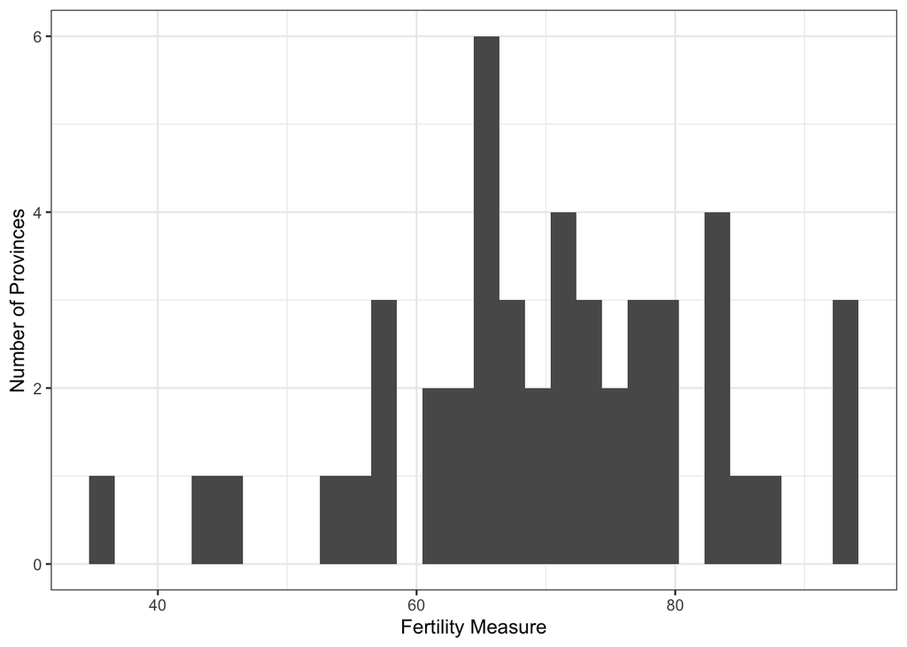

```r
ggplot(data = swiss1) +
  geom_histogram(mapping = aes(x = Fertility)) +
  labs(x = "Fertility Measure", y = "Number of Provinces") +
  theme_bw()
```

At first glance it appears that there might be some outliers of unusually low and high fertility.

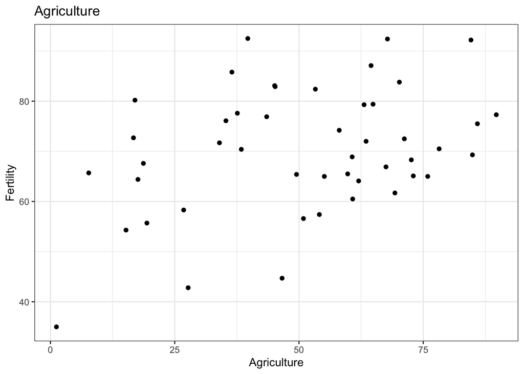

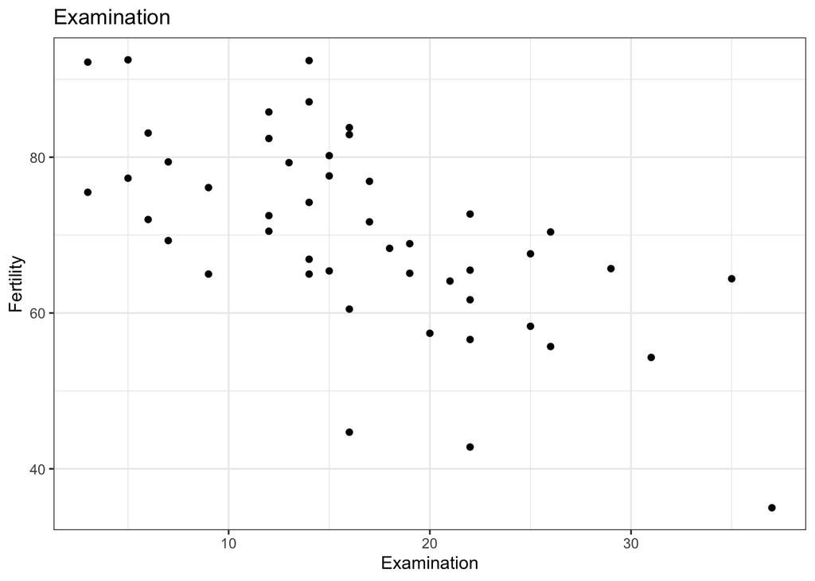

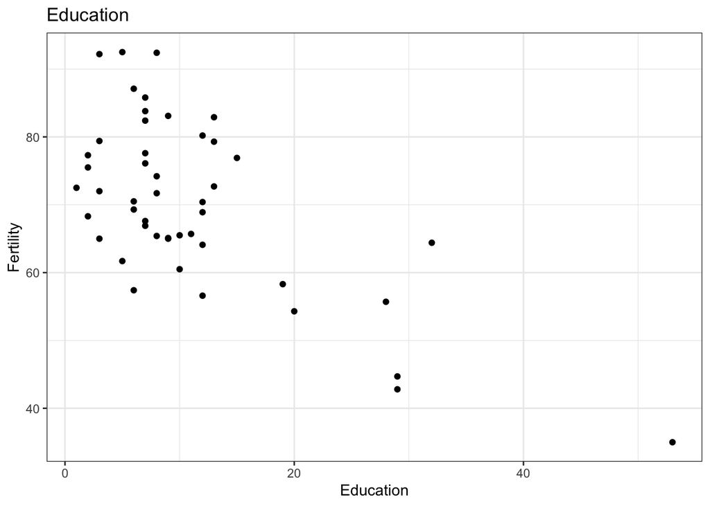

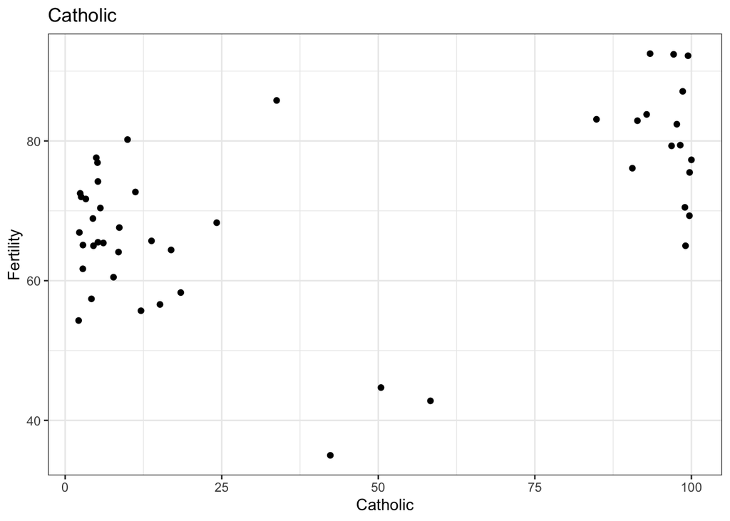

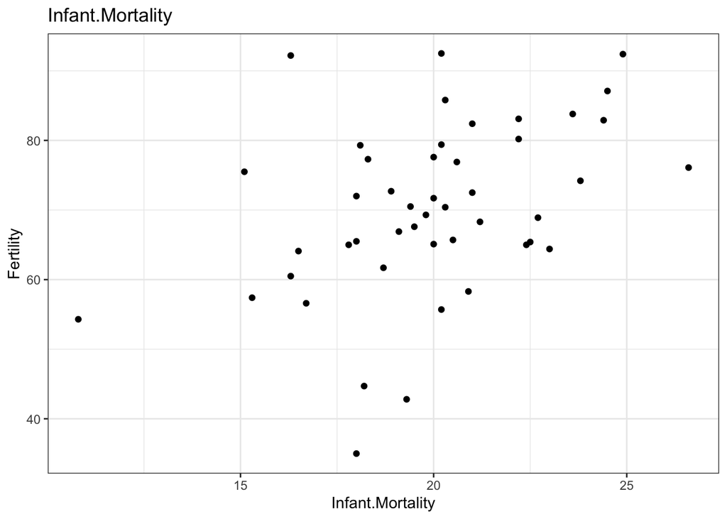

```r
for (var in c("Agriculture", "Examination", "Education", "Catholic", "Infant.Mortality")) {
  plot <- ggplot(data = swiss1) +
    geom_point(mapping = aes(x = get(var), y = Fertility)) +
    labs(x = var) + ggtitle(var) + theme_bw()
  print(plot)
}
```

There appears to be a distinct negative trend between `Examination` (% draftees receiving highest mark on army examination) and `Fertility`. Many of the provinces have a low percentage (0-20%) of draftees who were educated beyond primary school. There seems like there might be a relationship between `Fertility` and `Education`. The percent Catholic as opposed to Protestant seems to be in two groups. Generally provinces either had very high percentage of Catholics or quite low. There are few provinces with nearly 50-50 proportion between the two religions. We can try splitting `Catholic` into three levels `low`, `middle`, and `high`.

```r
swiss1 <- swiss1 %>%
  mutate(CatholicLevels = case_when(Catholic < 25 ~ "low",
                                    25 < Catholic & Catholic < 75 ~ "middle",
                                    75 < Catholic ~ "high")) %>%
  mutate(CatholicLevels = as.factor(CatholicLevels)) %>%
  print(width = Inf)
```

```
## # A tibble: 47 × 8
##    Province     Fertility Agriculture Examination Education Catholic
##    <chr>            <dbl>       <dbl>       <int>     <int>    <dbl>
##  1 Courtelary        80.2        17            15        12     9.96
##  2 Delemont          83.1        45.1           6         9    84.8
##  3 Franches-Mnt      92.5        39.7           5         5    93.4
##  4 Moutier           85.8        36.5          12         7    33.8
##  5 Neuveville        76.9        43.5          17        15     5.16
##  6 Porrentruy        76.1        35.3           9         7    90.6
##  7 Broye             83.8        70.2          16         7    92.8
##  8 Glane             92.4        67.8          14         8    97.2
##  9 Gruyere           82.4        53.3          12         7    97.7
## 10 Sarine            82.9        45.2          16        13    91.4
##    Infant.Mortality CatholicLevels
##               <dbl> <fct>
##  1             22.2 low
##  2             22.2 high
##  3             20.2 high
##  4             20.3 middle
##  5             20.6 low
##  6             26.6 high
##  7             23.6 high
##  8             24.9 high
##  9             21   high
## 10             24.4 high
## # … with 37 more rows
```

```r
swiss1 <- swiss1 %>%
  mutate(Catholic2 = case_when(Catholic < 75 ~ "low",
                                    75 < Catholic ~ "high")) %>%
  mutate(Catholic2 = as.factor(Catholic2)) %>%
  print(width = Inf)
```

```
## # A tibble: 47 × 9
##    Province     Fertility Agriculture Examination Education Catholic
##    <chr>            <dbl>       <dbl>       <int>     <int>    <dbl>
##  1 Courtelary        80.2        17            15        12     9.96
##  2 Delemont          83.1        45.1           6         9    84.8
##  3 Franches-Mnt      92.5        39.7           5         5    93.4
##  4 Moutier           85.8        36.5          12         7    33.8
##  5 Neuveville        76.9        43.5          17        15     5.16
##  6 Porrentruy        76.1        35.3           9         7    90.6
##  7 Broye             83.8        70.2          16         7    92.8
##  8 Glane             92.4        67.8          14         8    97.2
##  9 Gruyere           82.4        53.3          12         7    97.7
## 10 Sarine            82.9        45.2          16        13    91.4
##    Infant.Mortality CatholicLevels Catholic2
##               <dbl> <fct>          <fct>
##  1             22.2 low            low
##  2             22.2 high           high
##  3             20.2 high           high
##  4             20.3 middle         low
##  5             20.6 low            low
##  6             26.6 high           high
##  7             23.6 high           high
##  8             24.9 high           high
##  9             21   high           high
## 10             24.4 high           high
## # … with 37 more rows
```

### Variable Selection

For variable selection we start with a big model (`biglm`) that includes all two-way interactions between predictors. By step-wise regression, we minimize the AIC (Akaike Information Criterion) to get a small model (`smalllm`).

```r
lmod <- lm(Fertility ~ Agriculture + Examination + Education + Catholic2 + Infant.Mortality, swiss1)
summary(lmod)
```

```
##
## Call:
## lm(formula = Fertility ~ Agriculture + Examination + Education +
##     Catholic2 + Infant.Mortality, data = swiss1)
##
## Residuals:
##     Min      1Q  Median      3Q     Max
## -15.409  -4.741   0.031   3.726  15.111
##
## Coefficients:
##                   Estimate Std. Error t value Pr(>|t|)
## (Intercept)       78.54867   10.54610   7.448 3.87e-09 ***
## Agriculture       -0.17491    0.06685  -2.616 0.012386 *
## Examination       -0.24026    0.23294  -1.031 0.308384
## Education         -0.78143    0.16087  -4.858 1.77e-05 ***
## Catholic2low     -10.72261    2.91550  -3.678 0.000677 ***
## Infant.Mortality   1.00628    0.36609   2.749 0.008856 **
## ---
## Signif. codes:  0 '***' 0.001 '**' 0.01 '*' 0.05 '.' 0.1 ' ' 1
##
## Residual standard error: 6.842 on 41 degrees of freedom
## Multiple R-squared:  0.7326, Adjusted R-squared:    0.7
## F-statistic: 22.46 on 5 and 41 DF,  p-value: 8.874e-11
```

```r
biglm <- lm(Fertility ~ (Agriculture + Examination + Education + Catholic2 + Infant.Mortality)^2, swiss1)
smalllm <- stats::step(biglm, trace = TRUE)
```

```
## Start:  AIC=187.53
## Fertility ~ (Agriculture + Examination + Education + Catholic2 +
##     Infant.Mortality)^2
##
##                                Df Sum of Sq    RSS    AIC
## - Catholic2:Infant.Mortality    1     4.765 1290.9 185.71
## - Examination:Catholic2         1     5.379 1291.5 185.73
## - Education:Catholic2           1    21.880 1308.0 186.33
## - Education:Infant.Mortality    1    22.946 1309.0 186.36
## <none>                                      1286.1 187.53
## - Agriculture:Catholic2         1    56.746 1342.8 187.56
## - Examination:Infant.Mortality  1    60.641 1346.7 187.70
## - Agriculture:Education         1    69.511 1355.6 188.01
## - Agriculture:Examination       1   102.361 1388.5 189.13
## - Examination:Education         1   192.893 1479.0 192.10
## - Agriculture:Infant.Mortality  1   231.198 1517.3 193.30
##
## Step:  AIC=185.71
## Fertility ~ Agriculture + Examination + Education + Catholic2 +
##     Infant.Mortality + Agriculture:Examination + Agriculture:Education +
##     Agriculture:Catholic2 + Agriculture:Infant.Mortality + Examination:Education +
##     Examination:Catholic2 + Examination:Infant.Mortality + Education:Catholic2 +
##     Education:Infant.Mortality
##
##                                Df Sum of Sq    RSS    AIC
## - Examination:Catholic2         1     1.508 1292.4 183.76
## - Education:Catholic2           1    17.170 1308.0 184.33
## - Education:Infant.Mortality    1    32.437 1323.3 184.87
## - Agriculture:Catholic2         1    54.274 1345.1 185.64
## <none>                                      1290.9 185.71
## - Examination:Infant.Mortality  1    66.714 1357.6 186.07
## - Agriculture:Education         1    69.437 1360.3 186.17
## - Agriculture:Examination       1    97.758 1388.6 187.14
## - Examination:Education         1   188.599 1479.5 190.12
## - Agriculture:Infant.Mortality  1   227.248 1518.1 191.33
##
## Step:  AIC=183.76
## Fertility ~ Agriculture + Examination + Education + Catholic2 +
##     Infant.Mortality + Agriculture:Examination + Agriculture:Education +
##     Agriculture:Catholic2 + Agriculture:Infant.Mortality + Examination:Education +
```

[output cut: 42 more lines]

```
## - Examination:Infant.Mortality  1    239.41 1584.4 187.34
##
## Step:  AIC=181
## Fertility ~ Agriculture + Examination + Education + Catholic2 +
##     Infant.Mortality + Agriculture:Examination + Agriculture:Education +
##     Agriculture:Infant.Mortality + Examination:Education + Examination:Infant.Mortality
##
##                                Df Sum of Sq    RSS    AIC
## <none>                                      1384.5 181.00
## - Agriculture:Examination       1     68.39 1452.9 181.26
## - Agriculture:Education         1     85.24 1469.8 181.81
## - Examination:Education         1    178.71 1563.2 184.71
## - Agriculture:Infant.Mortality  1    276.39 1660.9 187.55
## - Examination:Infant.Mortality  1    346.48 1731.0 189.50
## - Catholic2                     1    592.29 1976.8 195.74
```

```r
drop1(smalllm, test = "F")
```

```
## Single term deletions
##
## Model:
## Fertility ~ Agriculture + Examination + Education + Catholic2 +
##     Infant.Mortality + Agriculture:Examination + Agriculture:Education +
##     Agriculture:Infant.Mortality + Examination:Education + Examination:Infant.Mortality
##                              Df Sum of Sq    RSS    AIC F value    Pr(>F)
## <none>                                    1384.5 181.00
## Catholic2                     1    592.29 1976.8 195.74 15.4004 0.0003758 ***
## Agriculture:Examination       1     68.39 1452.9 181.26  1.7782 0.1907481
## Agriculture:Education         1     85.24 1469.8 181.81  2.2164 0.1452608
## Agriculture:Infant.Mortality  1    276.39 1660.9 187.55  7.1865 0.0110120 *
## Examination:Education         1    178.71 1563.2 184.71  4.6466 0.0378746 *
## Examination:Infant.Mortality  1    346.48 1731.0 189.50  9.0090 0.0048580 **
## ---
## Signif. codes:  0 '***' 0.001 '**' 0.01 '*' 0.05 '.' 0.1 ' ' 1
```

The F-test shows that the `Agriculture:Examination` and `Agriculture:Education` interaction terms can be dropped from the model. Thus the model after dropping these interactions is:

```r
lmodf <- lm(Fertility ~ Agriculture + Examination + Education + Catholic2 +
              Infant.Mortality + Agriculture:Infant.Mortality + Examination:Education +
              Examination:Infant.Mortality, swiss1)
summary(lmodf)
```

```
##
## Call:
## lm(formula = Fertility ~ Agriculture + Examination + Education +
##     Catholic2 + Infant.Mortality + Agriculture:Infant.Mortality +
##     Examination:Education + Examination:Infant.Mortality, data = swiss1)
##
## Residuals:
##      Min       1Q   Median       3Q      Max
## -11.6495  -4.1217  -0.1656   3.2874  12.5300
##
## Coefficients:
##                                Estimate Std. Error t value Pr(>|t|)
## (Intercept)                  193.775560  46.141048   4.200 0.000155 ***
## Agriculture                   -1.287920   0.504980  -2.550 0.014911 *
## Examination                   -3.567697   1.264172  -2.822 0.007547 **
## Education                     -0.995448   0.343945  -2.894 0.006265 **
## Catholic2low                 -11.091710   2.872523  -3.861 0.000425 ***
## Infant.Mortality              -4.400419   2.177972  -2.020 0.050429 .
## Agriculture:Infant.Mortality   0.052486   0.024280   2.162 0.037006 *
## Examination:Education          0.005622   0.010777   0.522 0.604926
## Examination:Infant.Mortality   0.160338   0.061590   2.603 0.013097 *
## ---
## Signif. codes:  0 '***' 0.001 '**' 0.01 '*' 0.05 '.' 0.1 ' ' 1
##
## Residual standard error: 6.498 on 38 degrees of freedom
## Multiple R-squared:  0.7765, Adjusted R-squared:  0.7294
## F-statistic:  16.5 on 8 and 38 DF,  p-value: 3.267e-10
```

### Diagnostics

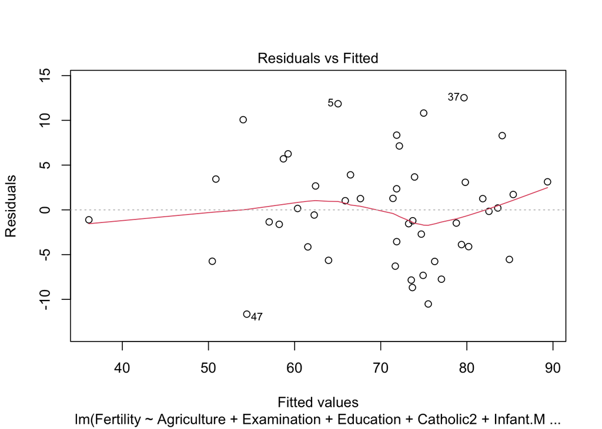

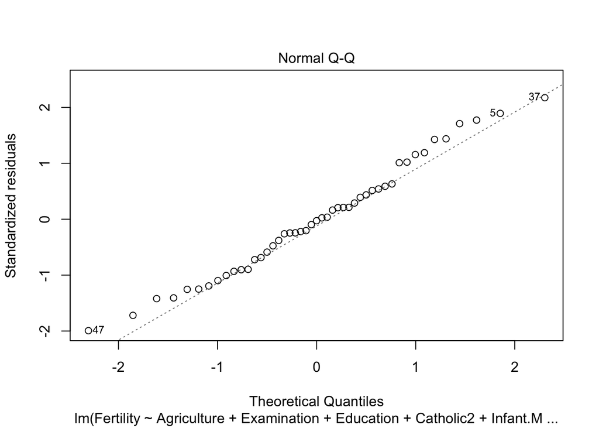

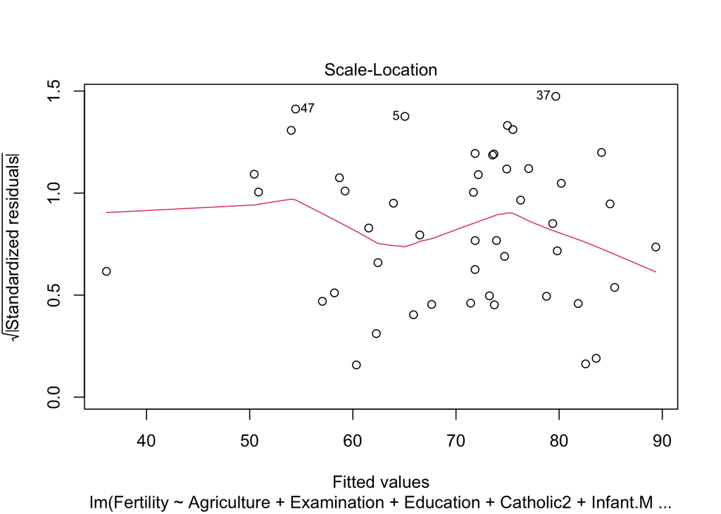

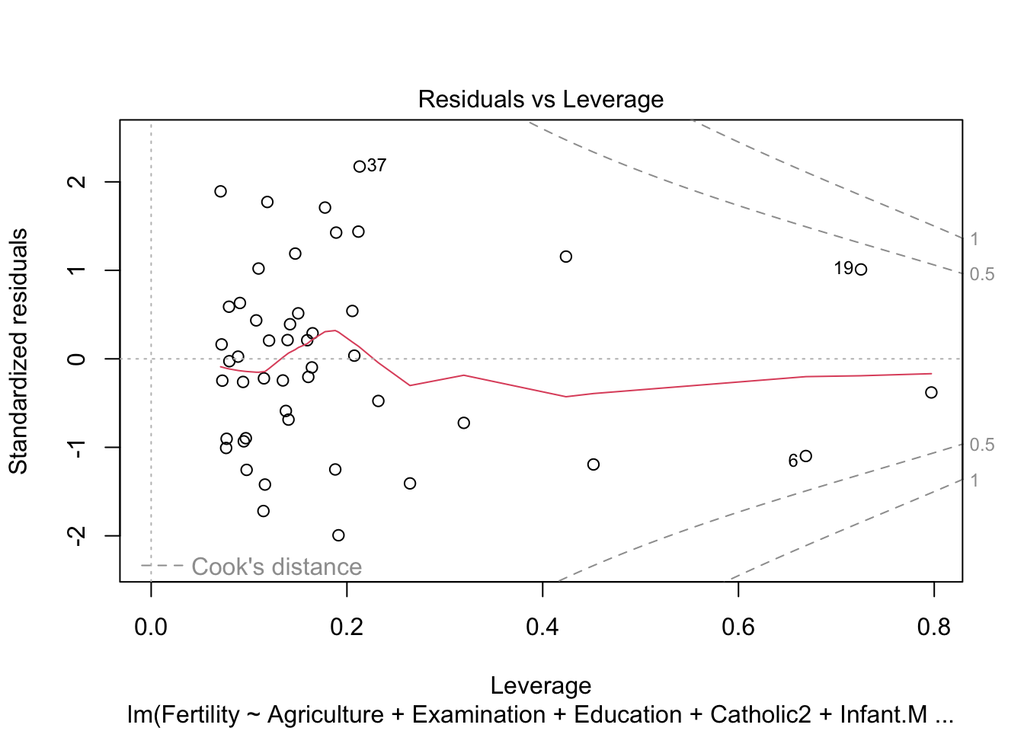

```r
plot(lmodf)
```

It appears the model assumptions are generally met. The Residuals vs Fitted plot shows the residuals randomly around zero. This means we are roughly meeting the linearity and constant variance assumptions. The Normal Q-Q plot is almost linear so we’ve met the normality assumption as well.

We can also look at the partial residuals for each component in the model without the interactions:

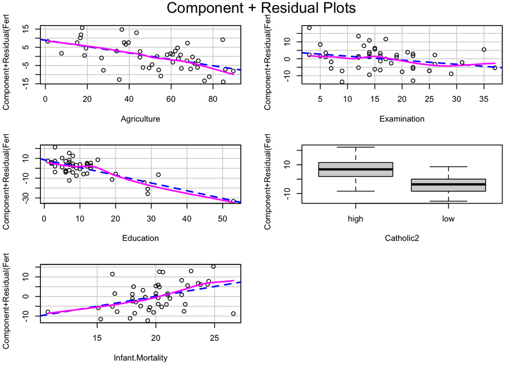

```r
crPlots(lmod)
```

The partial residual plots look mostly linear, but we can explore transforming `Examination`.

### Exploration of Transformations

The previous scatter plot of `Examination` and `Fertility` indicated that it might be helpful to transform `Examination` down the ladder of powers.

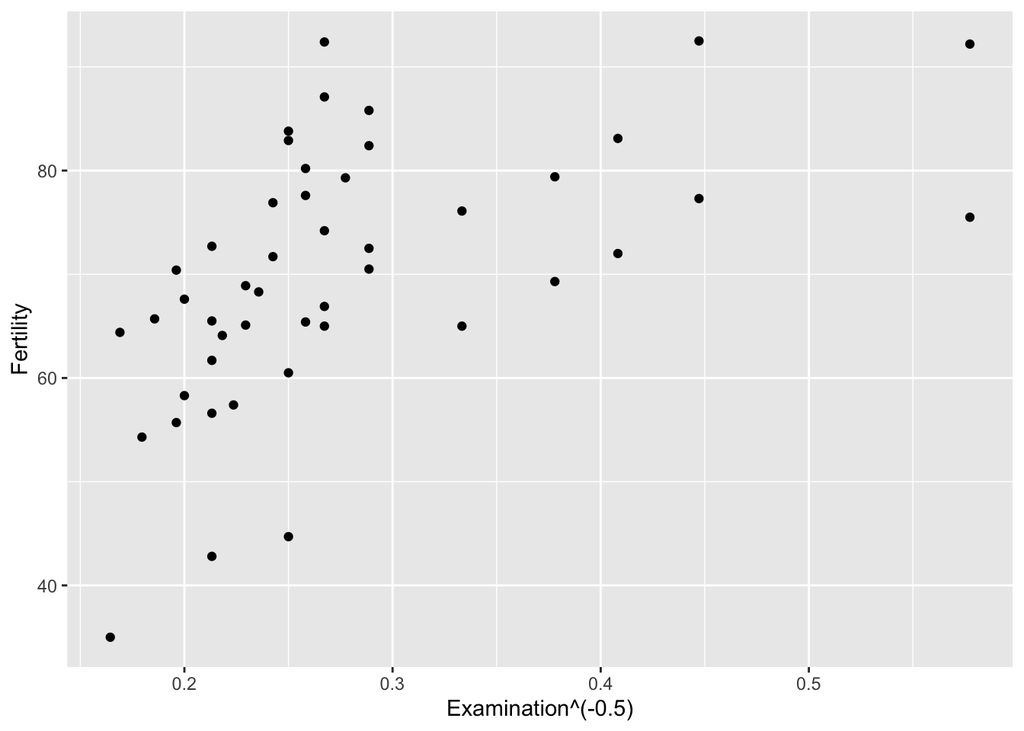

```r
ggplot(data = swiss1) +
    geom_point(mapping = aes(x = Examination^(-.5), y = Fertility))
```

The transformation seems to have made the scatterplot a little more linear.

```r
swiss1 <- swiss1 %>%
  mutate(TExam = Examination^(-.5)) %>%
  print(width = Inf)
```

```
## # A tibble: 47 × 10
##    Province     Fertility Agriculture Examination Education Catholic
##    <chr>            <dbl>       <dbl>       <int>     <int>    <dbl>
##  1 Courtelary        80.2        17            15        12     9.96
##  2 Delemont          83.1        45.1           6         9    84.8
##  3 Franches-Mnt      92.5        39.7           5         5    93.4
##  4 Moutier           85.8        36.5          12         7    33.8
##  5 Neuveville        76.9        43.5          17        15     5.16
##  6 Porrentruy        76.1        35.3           9         7    90.6
##  7 Broye             83.8        70.2          16         7    92.8
##  8 Glane             92.4        67.8          14         8    97.2
##  9 Gruyere           82.4        53.3          12         7    97.7
## 10 Sarine            82.9        45.2          16        13    91.4
##    Infant.Mortality CatholicLevels Catholic2 TExam
##               <dbl> <fct>          <fct>     <dbl>
##  1             22.2 low            low       0.258
##  2             22.2 high           high      0.408
##  3             20.2 high           high      0.447
##  4             20.3 middle         low       0.289
##  5             20.6 low            low       0.243
##  6             26.6 high           high      0.333
##  7             23.6 high           high      0.25
##  8             24.9 high           high      0.267
##  9             21   high           high      0.289
## 10             24.4 high           high      0.25
## # … with 37 more rows
```

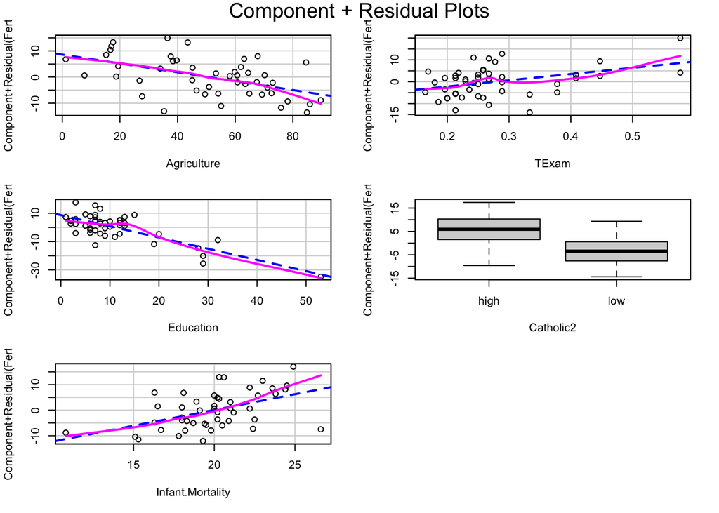

```r
trlm <- lm(Fertility ~ Agriculture + TExam + Education +
             Catholic2 + Infant.Mortality, swiss1)
crPlots(trlm)
```

The fit doesn’t improve the diagnostics, so we can continue without transformations.

### Final Model

```r
lmodf %>%
  tbl_regression() %>%
  bold_labels() %>%
  bold_p(t = 0.05)
```

| **Characteristic** | **Beta** | **95% CI**<sup>1</sup> | **p-value** |
| --- | --- | --- | --- |
| Agriculture | -1.3 | -2.3, -0.27 | 0.015 |
| Examination | -3.6 | -6.1, -1.0 | 0.008 |
| Education | -1.0 | -1.7, -0.30 | 0.006 |
| Catholic2 |  |  |  |
| high | — | — |  |
| low | -11 | -17, -5.3 | <0.001 |
| Infant.Mortality | -4.4 | -8.8, 0.01 | 0.050 |
| Agriculture * Infant.Mortality | 0.05 | 0.00, 0.10 | 0.037 |
| Examination * Education | 0.01 | -0.02, 0.03 | 0.6 |
| Examination * Infant.Mortality | 0.16 | 0.04, 0.29 | 0.013 |

<sup>1</sup> CI = Confidence Interval

#### Diagnostics

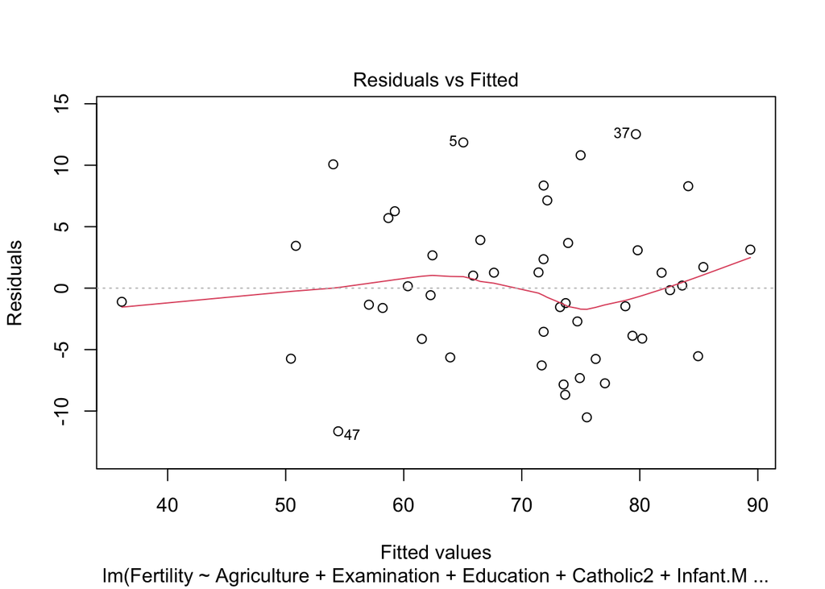

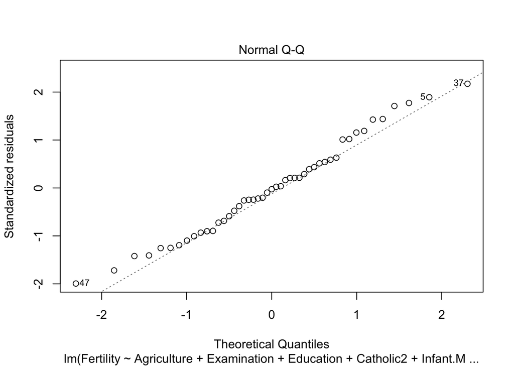

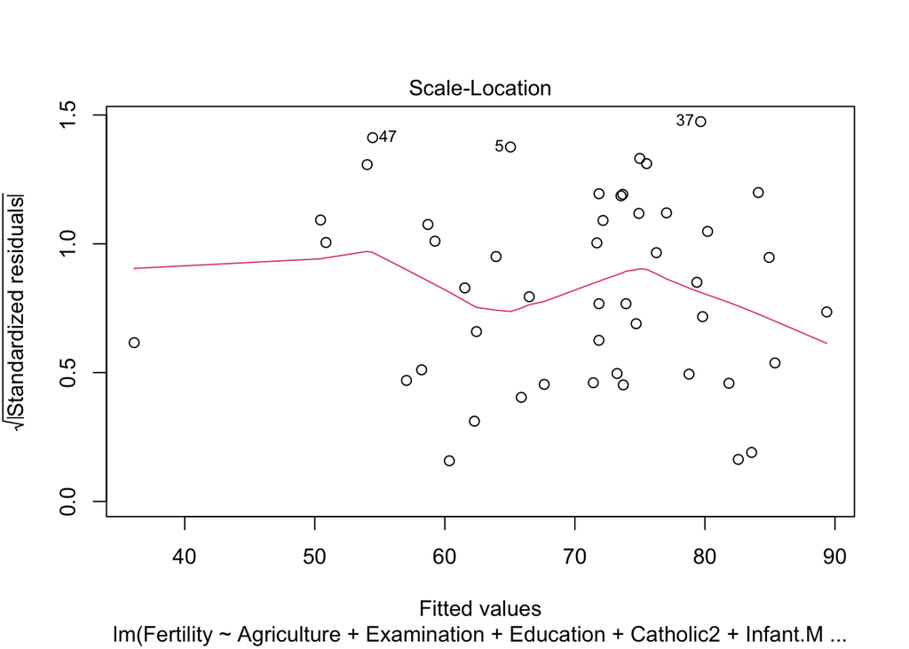

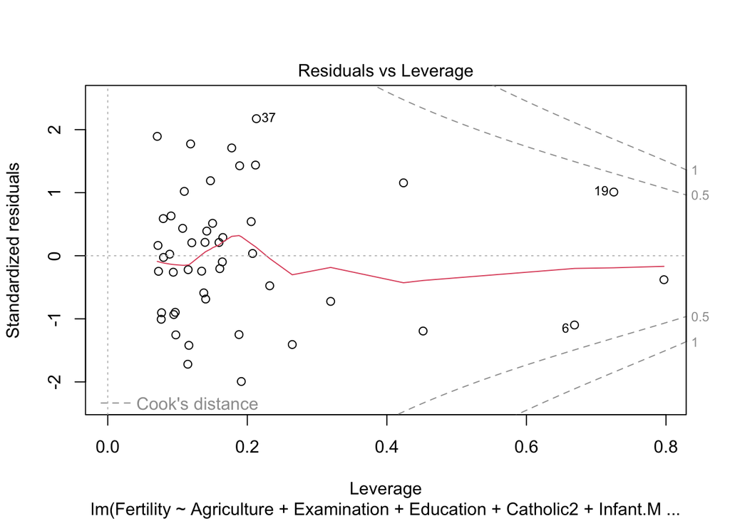

```r
plot(lmodf)
```

```r
swiss1 %>%
  mutate(cook = cooks.distance(lmodf)) %>%
  filter(cook >= 0.1) %>%
  print(width = Inf)
```

```
## # A tibble: 6 × 11
##   Province    Fertility Agriculture Examination Education Catholic
##   <chr>           <dbl>       <dbl>       <int>     <int>    <dbl>
## 1 Porrentruy       76.1        35.3           9         7    90.6
## 2 La Vallee        54.3        15.2          31        20     2.15
## 3 Sierre           92.2        84.6           3         3    99.5
## 4 Neuchatel        64.4        17.6          35        32    16.9
## 5 Rive Droite      44.7        46.6          16        29    50.4
## 6 Rive Gauche      42.8        27.7          22        29    58.3
##   Infant.Mortality CatholicLevels Catholic2 TExam  cook
##              <dbl> <fct>          <fct>     <dbl> <dbl>
## 1             26.6 high           high      0.333 0.271
## 2             10.8 low            low       0.180 0.299
## 3             16.3 high           high      0.577 0.142
## 4             23   low            low       0.169 0.109
## 5             18.2 middle         low       0.25  0.130
## 6             19.3 middle         low       0.213 0.105
```

There are some observations with cook’s distances higher than 0.1 but there’s no clear reason why that might be the case, and no indication that they might be outliers.

### Predictions

- Some predictions of future observations for interesting values of the predictors. Let’s predict the fertility of a few random provinces in Switzerland with median `Agriculture`; `Examination` at the observed minimum, 1st quartile, median, 3rd quartile, and maximum; minimum `Education`; either level of `Catholic` and maximum `Infant.Mortality`.

```r
pdf <- tibble(Agriculture = rep(median(swiss1$Agriculture), 5),
              Examination = c(3, 12, 16, 22, 37),
              Education = rep(1, 5),
              Catholic2 = c("high", "low", "high", "low", "high"),
              Infant.Mortality = rep(26.6, 5))
print(pdf)
```

```
## # A tibble: 5 × 5
##   Agriculture Examination Education Catholic2 Infant.Mortality
##         <dbl>       <dbl>     <dbl> <chr>                <dbl>
## 1        54.1           3         1 high                  26.6
## 2        54.1          12         1 low                   26.6
## 3        54.1          16         1 high                  26.6
## 4        54.1          22         1 low                   26.6
## 5        54.1          37         1 high                  26.6
```

```r
pp <- predict(lmodf, new = pdf)
pdf %>% mutate(PredictedFertility = pp)
```

```
## # A tibble: 5 × 6
##   Agriculture Examination Education Catholic2 Infant.Mortality PredictedFertil…¹
##         <dbl>       <dbl>     <dbl> <chr>                <dbl>             <dbl>
## 1        54.1           3         1 high                  26.6              83.7
## 2        54.1          12         1 low                   26.6              78.9
## 3        54.1          16         1 high                  26.6              92.8
## 4        54.1          22         1 low                   26.6              86.0
## 5        54.1          37         1 high                  26.6             108.
## # … with abbreviated variable name ¹PredictedFertility
```

It’s interesting that a hypothetical province with average percentage of males involved in agriculture, maximum percentage of draftees with highest marks on army examination, lowest percentage of education beyond primary school, high percentage of Catholics, and maximum observed infant mortality has a predicted fertility that would be even higher than the Hutterites since the percent fertility is expected to be above 100%.

## Q2. Concavity of logistic regression log-likelihood

### Q2.1 Log-likelihood function of logistic regression

Write down the log-likelihood function of logistic regression for Bernoulli responses.

Given $n$ data points $(y_i, \mathbf{x}_i)$, $i=1,\ldots,n$, the **log-likelihood** is
$$\begin{eqnarray*}
\ell(\boldsymbol{\beta}) &=& \sum_i \log \left[p_i^{y_i} (1 -
p_i)^{1 - y_i}\right] \\
&=& \sum_i \left[ y_i \log p_i + (1 - y_i) \log (1 - p_i)
\right] \\
&=& \sum_i \left[ y_i \log \frac{e^{\eta_i}}{1 + e^{\eta_i}} +
(1 - y_i) \log \frac{1}{1 + e^{\eta_i}} \right] \\
&=& \sum_i \left[ y_i \eta_i - \log (1 + e^{\eta_i}) \right] \\
&=& \sum_i \left[ y_i \cdot \mathbf{x}_i^T \boldsymbol{\beta} -
\log (1 + e^{\mathbf{x}_i^T \boldsymbol{\beta}}) \right].
\end{eqnarray*}$$

### Q2.2 Gradient vector and Hessian matrix

Derive the gradient vector and Hessian matrix of the log-likelihood function with respect to the regression coefficients $\boldsymbol{\beta}$.

$$\begin{eqnarray*}
\ell(\boldsymbol{\beta}, x_i, y_i) &=& \sum_i \left[ y_i \cdot
\mathbf{x}_i^T \boldsymbol{\beta} - \log (1 + e^{\mathbf{x}_i^T
\boldsymbol{\beta}}) \right] \\
\nabla_\beta(\mathbf{x}_i^T \boldsymbol{\beta}) &=&
\nabla_\beta(\mathbf{x}_{i0} \beta_0 + \mathbf{x}_{i1} \beta_1 + \cdots
+ \mathbf{x}_{ip} \beta_p)
&=& \boldsymbol{\mathbf{x}_i} \\
\nabla_\beta \ell(\cdot) &=& \sum_i y_i(\nabla_\beta
\mathbf{x}_i^T \boldsymbol{\beta}) - \nabla_\beta (\log (1 +
e^{\mathbf{x}_i^T \boldsymbol{\beta}})) \\
&=& \sum_i y_i \mathbf{x}_i - \frac{1}{1 + e^{\mathbf{x}_i^T
\boldsymbol{\beta}}} \cdot e^{\mathbf{x}_i^T \boldsymbol{\beta}} \cdot
\nabla_\beta \mathbf{x}_i^T \boldsymbol{\beta} \\
&=& \sum_i y_i \mathbf{x}_i - \frac{e^{\mathbf{x}_i^T
\boldsymbol{\beta}}}{1 + e^{\mathbf{x}_i^T \boldsymbol{\beta}}} \cdot
\mathbf{x}_i \\
&=& \sum_i y_i \mathbf{x}_i - \frac{1}{1 + e^{- \mathbf{x}_i^T
\boldsymbol{\beta}}} \cdot \mathbf{x}_i
\end{eqnarray*}$$

The Hessian is the matrix of the partial derivatives of the gradient vector with respect to $\boldsymbol{\beta}$.

$$\begin{eqnarray*}
\nabla_\beta(\frac{\partial \ell(\cdot)}{\partial \beta_j}) &=&
\sum_i \nabla_\beta(y_i x_{ij} - \frac{1}{1 + e^{- \mathbf{x}_i^T
\boldsymbol{\beta}}} x_{ij}) \\
&=& \sum_i \nabla_\beta(-x_{ij}(1 + e^{- \mathbf{x}_i^T
\boldsymbol{\beta}})^{-1}) \\
&=& \sum_i -x_{ij} \cdot -1(1 + e^{- \mathbf{x}_i^T
\boldsymbol{\beta}})^{-2} e^{- \mathbf{x}_i^T \boldsymbol{\beta}}
\mathbf{x}_i \\
&=& - \sum_i x_{ij} \frac{e^{- \mathbf{x}_i^T
\boldsymbol{\beta}}}{1 + e^{- \mathbf{x}_i^T \boldsymbol{\beta}}}
\mathbf{x}_i \\
&=& - \sum_i \begin{bmatrix}
x_{i0} \frac{e^{- \mathbf{x}_i^T \boldsymbol{\beta}}}{(1 + e^{-
\mathbf{x}_i^T \boldsymbol{\beta}})^{2}} \mathbf{x}_i & \cdots &
x_{ip} \frac{e^{- \mathbf{x}_i^T \boldsymbol{\beta}}}{(1 + e^{-
\mathbf{x}_i^T \boldsymbol{\beta}})^{2}} \mathbf{x}_i \\
\end{bmatrix} \\
&=& - \sum_i \frac{e^{- \mathbf{x}_i^T \boldsymbol{\beta}}}{(1 +
e^{- \mathbf{x}_i^T \boldsymbol{\beta}})^{2}} \begin{bmatrix}
x_{i0} \mathbf{x}_i & \cdots & x_{ip} \mathbf{x}_i
\end{bmatrix} \\
&=& - \sum_i \frac{e^{- \mathbf{x}_i^T \boldsymbol{\beta}}}{(1 +
e^{- \mathbf{x}_i^T \boldsymbol{\beta}})^{2}} \mathbf{x}_i
\begin{bmatrix}
x_{i0} & \cdots & x_{ip}
\end{bmatrix} \\
&=& - \sum_i \frac{e^{- \mathbf{x}_i^T \boldsymbol{\beta}}}{(1 +
e^{- \mathbf{x}_i^T \boldsymbol{\beta}})^{2}} \mathbf{x}_i
\mathbf{x}_i^T = H_\beta
\end{eqnarray*}$$

### Q2.3 Concavity

Show that the log-likelihood function of logistic regression is a concave function in regression coefficients $\boldsymbol{\beta}$. (Hint: show that the negative Hessian is a positive semidefinite matrix.)

If we combine the scalar terms into a diagnoal matrix D and concatenate column vectors $x_i \in \mathbb{R}^{d}$ into a matrix $\mathbf{X}$ of size $d \times m$ such that $\sum_i^{m} \mathbf{x}_i \mathbf{x}_i^T = \mathbf{XX}^T$. The scalar terms are collected into a diagonal matrix $D$ such that $-H_\beta = XDX^T$. Let $\delta$ be any vector such that $\delta \in \mathbb{R}^{d}$. Then we can show that $\delta^T(-H_\beta)\delta \ge 0$ to show that the negative Hessian is a positive semi-definite matrix and thus the log-likelihood function of logistic regression is a concave function.

$$\begin{eqnarray*}
\delta^T H \delta &=& \delta^TXDX^T\delta &=&
\delta^TXD(\delta^TX)^T &=& \lVert \delta^T DX \rVert^{2} \ge 0
\end{eqnarray*}$$

## Q3. Analysis of Diabetes Among Pima Indians

The National Institute of Diabetes and Digestive and Kidney Diseases conducted a study on 768 adult female Pima Indians living near Phoenix. The purpose of the study was to investigate factors related to diabetes. The data may be found in the the dataset `pima`.

```r
library(faraway)
library(tidyverse)
pima1 <- as_tibble(pima) %>%
  print(width = Inf)
```

```
## # A tibble: 768 × 9
##    pregnant glucose diastolic triceps insulin   bmi diabetes   age  test
##       <int>   <int>     <int>   <int>   <int> <dbl>    <dbl> <int> <int>
##  1        6     148        72      35       0  33.6    0.627    50     1
##  2        1      85        66      29       0  26.6    0.351    31     0
##  3        8     183        64       0       0  23.3    0.672    32     1
##  4        1      89        66      23      94  28.1    0.167    21     0
##  5        0     137        40      35     168  43.1    2.29     33     1
##  6        5     116        74       0       0  25.6    0.201    30     0
##  7        3      78        50      32      88  31      0.248    26     1
##  8       10     115         0       0       0  35.3    0.134    29     0
##  9        2     197        70      45     543  30.5    0.158    53     1
## 10        8     125        96       0       0   0      0.232    54     1
## # … with 758 more rows
```

```r
str(pima1)
```

```
## tibble [768 × 9] (S3: tbl_df/tbl/data.frame)
##  $ pregnant : int [1:768] 6 1 8 1 0 5 3 10 2 8 ...
##  $ glucose  : int [1:768] 148 85 183 89 137 116 78 115 197 125 ...
##  $ diastolic: int [1:768] 72 66 64 66 40 74 50 0 70 96 ...
##  $ triceps  : int [1:768] 35 29 0 23 35 0 32 0 45 0 ...
##  $ insulin  : int [1:768] 0 0 0 94 168 0 88 0 543 0 ...
##  $ bmi      : num [1:768] 33.6 26.6 23.3 28.1 43.1 25.6 31 35.3 30.5 0 ...
##  $ diabetes : num [1:768] 0.627 0.351 0.672 0.167 2.288 ...
##  $ age      : int [1:768] 50 31 32 21 33 30 26 29 53 54 ...
##  $ test     : int [1:768] 1 0 1 0 1 0 1 0 1 1 ...
```

### Q3.1

Create a factor version of the test results and use this to produce an interleaved histogram to show how the distribution of insulin differs between those testing positive and negative. Do you notice anything unbelievable about the plot?

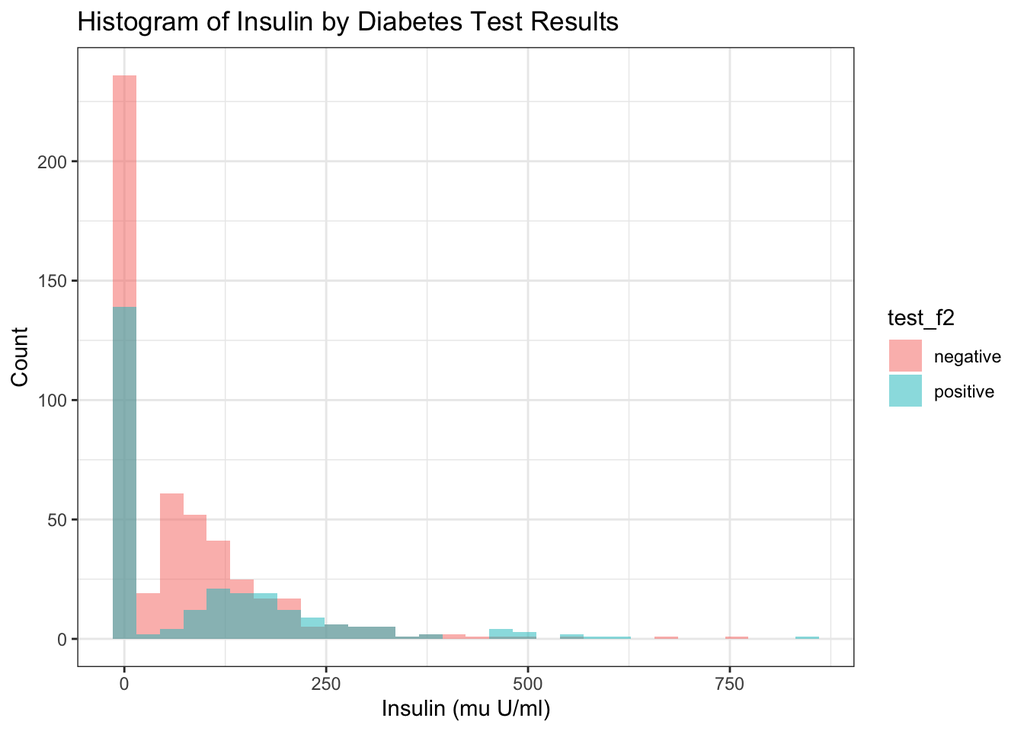

```r
pima1$test_f <- as.factor(pima1$test)
pima1$test_f2 <- pima1$test_f
levels(pima1$test_f2) <- c("negative", "positive")
ggplot(pima1, aes(x = insulin, fill = test_f2)) +
  geom_histogram(alpha =.5, position = "identity") +
  ylab("Count") + xlab("Insulin (mu U/ml)") +
  ggtitle("Histogram of Insulin by Diabetes Test Results") +
  theme_bw()
```

It’s unusual that there are so many entries of 0 Insulin, even for both positive and negative tested patients. It’s impossible to have 0 insulin in the body so the zeros must be missing values.

### Q3.2

Replace the zero values of `insulin` with the missing value code `NA`. Re-create the interleaved histogram plot and comment on the distribution.

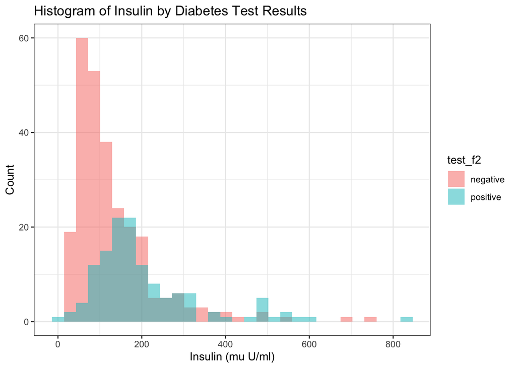

```r
pima1$insulin[pima1$insulin == 0] <- NA
ggplot(pima1, aes(x = insulin, fill = test_f2)) +
  geom_histogram(alpha =.5, position = "identity") +
  ylab("Count") + xlab("Insulin (mu U/ml)") +
  ggtitle("Histogram of Insulin by Diabetes Test Results") +
  theme_bw()
```

The peak insulin level of those who tested negative is now lower than that of those who tested positive for diabetes. The distribution of those with a negative test looks right skewed. There also looks like there might be some outliers with unusually high insulin levels.

### Q3.3

Replace the incredible zeroes in other variables with the missing value code. Fit a model with the result of the diabetes test as the response and all the other variables as predictors. How many observations were used in the model fitting? Why is this less than the number of observations in the data frame?

```r
summary(pima1)
```

```
##     pregnant         glucose        diastolic         triceps
##  Min.   : 0.000   Min.   :  0.0   Min.   :  0.00   Min.   : 0.00
##  1st Qu.: 1.000   1st Qu.: 99.0   1st Qu.: 62.00   1st Qu.: 0.00
##  Median : 3.000   Median :117.0   Median : 72.00   Median :23.00
##  Mean   : 3.845   Mean   :120.9   Mean   : 69.11   Mean   :20.54
##  3rd Qu.: 6.000   3rd Qu.:140.2   3rd Qu.: 80.00   3rd Qu.:32.00
##  Max.   :17.000   Max.   :199.0   Max.   :122.00   Max.   :99.00
##
##     insulin            bmi           diabetes           age
##  Min.   : 14.00   Min.   : 0.00   Min.   :0.0780   Min.   :21.00
##  1st Qu.: 76.25   1st Qu.:27.30   1st Qu.:0.2437   1st Qu.:24.00
##  Median :125.00   Median :32.00   Median :0.3725   Median :29.00
##  Mean   :155.55   Mean   :31.99   Mean   :0.4719   Mean   :33.24
##  3rd Qu.:190.00   3rd Qu.:36.60   3rd Qu.:0.6262   3rd Qu.:41.00
##  Max.   :846.00   Max.   :67.10   Max.   :2.4200   Max.   :81.00
##  NA's   :374
##       test       test_f      test_f2
##  Min.   :0.000   0:500   negative:500
##  1st Qu.:0.000   1:268   positive:268
##  Median :0.000
##  Mean   :0.349
##  3rd Qu.:1.000
##  Max.   :1.000
##
```

The summary shows that `glucose`, `diastolic`, `triceps`, and `bmi`also have zero values that don’t make sense.

```r
pima1$glucose[pima1$glucose == 0] <- NA
pima1$diastolic[pima1$diastolic == 0] <- NA
pima1$triceps[pima1$triceps == 0] <- NA
pima1$bmi[pima1$bmi == 0] <- NA
summary(pima1)
```

```
##     pregnant         glucose        diastolic         triceps
##  Min.   : 0.000   Min.   : 44.0   Min.   : 24.00   Min.   : 7.00
##  1st Qu.: 1.000   1st Qu.: 99.0   1st Qu.: 64.00   1st Qu.:22.00
##  Median : 3.000   Median :117.0   Median : 72.00   Median :29.00
##  Mean   : 3.845   Mean   :121.7   Mean   : 72.41   Mean   :29.15
##  3rd Qu.: 6.000   3rd Qu.:141.0   3rd Qu.: 80.00   3rd Qu.:36.00
##  Max.   :17.000   Max.   :199.0   Max.   :122.00   Max.   :99.00
##                   NA's   :5       NA's   :35       NA's   :227
##     insulin            bmi           diabetes           age
##  Min.   : 14.00   Min.   :18.20   Min.   :0.0780   Min.   :21.00
##  1st Qu.: 76.25   1st Qu.:27.50   1st Qu.:0.2437   1st Qu.:24.00
##  Median :125.00   Median :32.30   Median :0.3725   Median :29.00
##  Mean   :155.55   Mean   :32.46   Mean   :0.4719   Mean   :33.24
##  3rd Qu.:190.00   3rd Qu.:36.60   3rd Qu.:0.6262   3rd Qu.:41.00
##  Max.   :846.00   Max.   :67.10   Max.   :2.4200   Max.   :81.00
##  NA's   :374      NA's   :11
##       test       test_f      test_f2
##  Min.   :0.000   0:500   negative:500
##  1st Qu.:0.000   1:268   positive:268
##  Median :0.000
##  Mean   :0.349
##  3rd Qu.:1.000
##  Max.   :1.000
##
```

```r
# Diabetes Test Model
dtm <- glm(test_f ~ pregnant + glucose + diastolic + triceps + insulin + bmi +
             diabetes + age,
           family = "binomial", data = pima1)
summary(dtm)
```

```
##
## Call:
## glm(formula = test_f ~ pregnant + glucose + diastolic + triceps +
##     insulin + bmi + diabetes + age, family = "binomial", data = pima1)
##
## Deviance Residuals:
##     Min       1Q   Median       3Q      Max
## -2.7823  -0.6603  -0.3642   0.6409   2.5612
##
## Coefficients:
##               Estimate Std. Error z value Pr(>|z|)
## (Intercept) -1.004e+01  1.218e+00  -8.246  < 2e-16 ***
## pregnant     8.216e-02  5.543e-02   1.482  0.13825
## glucose      3.827e-02  5.768e-03   6.635 3.24e-11 ***
## diastolic   -1.420e-03  1.183e-02  -0.120  0.90446
## triceps      1.122e-02  1.708e-02   0.657  0.51128
## insulin     -8.253e-04  1.306e-03  -0.632  0.52757
## bmi          7.054e-02  2.734e-02   2.580  0.00989 **
## diabetes     1.141e+00  4.274e-01   2.669  0.00760 **
## age          3.395e-02  1.838e-02   1.847  0.06474 .
## ---
## Signif. codes:  0 '***' 0.001 '**' 0.01 '*' 0.05 '.' 0.1 ' ' 1
##
## (Dispersion parameter for binomial family taken to be 1)
##
##     Null deviance: 498.10  on 391  degrees of freedom
## Residual deviance: 344.02  on 383  degrees of freedom
##   (376 observations deleted due to missingness)
## AIC: 362.02
##
## Number of Fisher Scoring iterations: 5
```

There were 392 observations used in the model fitting. This is different from the number of observations because 376 observations were omitted due to missingness.

### Q3.4

Refit the model but now without the insulin and triceps predictors. How many observations were used in fitting this model? Devise a test to compare this model with that in the previous question.

```r
# Diabetes Test Model 2
dtm2 <- glm(test_f ~ pregnant + glucose + diastolic + bmi + diabetes + age,
           family = "binomial", data = pima1)
summary(dtm2)
```

```
##
## Call:
## glm(formula = test_f ~ pregnant + glucose + diastolic + bmi +
##     diabetes + age, family = "binomial", data = pima1)
##
## Deviance Residuals:
##     Min       1Q   Median       3Q      Max
## -2.8062  -0.7229  -0.4049   0.7173   2.3959
##
## Coefficients:
##              Estimate Std. Error z value Pr(>|z|)
## (Intercept) -8.962146   0.820892 -10.918  < 2e-16 ***
## pregnant     0.117863   0.033418   3.527  0.00042 ***
## glucose      0.035194   0.003605   9.763  < 2e-16 ***
## diastolic   -0.008916   0.008618  -1.035  0.30084
## bmi          0.090926   0.015740   5.777 7.61e-09 ***
## diabetes     0.960515   0.306415   3.135  0.00172 **
## age          0.016944   0.009834   1.723  0.08489 .
## ---
## Signif. codes:  0 '***' 0.001 '**' 0.01 '*' 0.05 '.' 0.1 ' ' 1
##
## (Dispersion parameter for binomial family taken to be 1)
##
##     Null deviance: 931.94  on 723  degrees of freedom
## Residual deviance: 672.86  on 717  degrees of freedom
##   (44 observations deleted due to missingness)
## AIC: 686.86
##
## Number of Fisher Scoring iterations: 5
```

The model without insulin or triceps used 724 observation. There were 44 observations omitted due to missingness. To compare this model with the previous model our null hypothesis is that the addition of `insulin` and `triceps` as predictors does not improve model fit, and the alternative hypothesis is that their addition does improve model fit. To assess whether the full model is superior to the reduced model (diabetes test model 2 versus model 1), we can take the differences in deviance of the two models and compute the chi-square test statistic. The residual deviance in model 1 is 344.02 on 383 degrees of freedom, and in model 2 is 672.86 on 717 degrees of freedom. So the chi-square test statistic is $672.86 - 344.02 = 328.84$ on $717 - 383 = 334$ degrees of freedom. We compute the p-value:

```r
dtm <- glm(test_f ~ pregnant + glucose + diastolic + triceps + insulin + bmi +
             diabetes + age,
           family = "binomial", data = na.omit(pima1))
dtm2 <- glm(test_f ~ pregnant + glucose + diastolic + bmi + diabetes + age,
           family = "binomial", data = na.omit(pima1))
anova(dtm, dtm2, test = "Chi")
```

```
## Analysis of Deviance Table
##
## Model 1: test_f ~ pregnant + glucose + diastolic + triceps + insulin +
##     bmi + diabetes + age
## Model 2: test_f ~ pregnant + glucose + diastolic + bmi + diabetes + age
##   Resid. Df Resid. Dev Df Deviance Pr(>Chi)
## 1       383     344.02
## 2       385     344.88 -2 -0.85931   0.6507
```

The p-value is high so we accept the null hypothesis that the addition of `insulin` and `triceps` as predictors does not improve model fit.

### Q3.5

Use AIC to select a model. You will need to take account of the missing values. Which predictors are selected? How many cases are used in your selected model?

```r
bigdtm <- glm(test_f ~ pregnant + glucose + diastolic + triceps + insulin + bmi +
             diabetes + age, family = binomial, data = na.omit(pima1))
smalldtm <- stats::step(bigdtm, trace = TRUE)
```

```
## Start:  AIC=362.02
## test_f ~ pregnant + glucose + diastolic + triceps + insulin +
##     bmi + diabetes + age
##
##             Df Deviance    AIC
## - diastolic  1   344.04 360.04
## - insulin    1   344.42 360.42
## - triceps    1   344.45 360.45
## <none>           344.02 362.02
## - pregnant   1   346.24 362.24
## - age        1   347.55 363.55
## - bmi        1   350.89 366.89
## - diabetes   1   351.58 367.58
## - glucose    1   396.95 412.95
##
## Step:  AIC=360.04
## test_f ~ pregnant + glucose + triceps + insulin + bmi + diabetes +
##     age
##
##            Df Deviance    AIC
## - insulin   1   344.42 358.42
## - triceps   1   344.46 358.46
## <none>          344.04 360.04
## - pregnant  1   346.24 360.24
## - age       1   347.60 361.60
## - bmi       1   351.28 365.28
## - diabetes  1   351.67 365.67
## - glucose   1   397.31 411.31
##
## Step:  AIC=358.42
## test_f ~ pregnant + glucose + triceps + bmi + diabetes + age
##
##            Df Deviance    AIC
## - triceps   1   344.89 356.89
## <none>          344.42 358.42
## - pregnant  1   346.74 358.74
## - age       1   347.87 359.87
## - bmi       1   351.32 363.32
## - diabetes  1   351.90 363.90
## - glucose   1   411.11 423.11
##
## Step:  AIC=356.89
## test_f ~ pregnant + glucose + bmi + diabetes + age
##
##            Df Deviance    AIC
## <none>          344.89 356.89
## - pregnant  1   347.23 357.23
## - age       1   348.72 358.72
## - diabetes  1   352.72 362.72
## - bmi       1   360.44 370.44
## - glucose   1   411.85 421.85
```

```r
summary(smalldtm)
```

```
##
## Call:
## glm(formula = test_f ~ pregnant + glucose + bmi + diabetes +
##     age, family = binomial, data = na.omit(pima1))
##
## Deviance Residuals:
##     Min       1Q   Median       3Q      Max
## -2.8827  -0.6535  -0.3694   0.6521   2.5814
##
## Coefficients:
##              Estimate Std. Error z value Pr(>|z|)
## (Intercept) -9.992080   1.086866  -9.193  < 2e-16 ***
## pregnant     0.083953   0.055031   1.526 0.127117
## glucose      0.036458   0.004978   7.324 2.41e-13 ***
## bmi          0.078139   0.020605   3.792 0.000149 ***
## diabetes     1.150913   0.424242   2.713 0.006670 **
## age          0.034360   0.017810   1.929 0.053692 .
## ---
## Signif. codes:  0 '***' 0.001 '**' 0.01 '*' 0.05 '.' 0.1 ' ' 1
##
## (Dispersion parameter for binomial family taken to be 1)
##
##     Null deviance: 498.10  on 391  degrees of freedom
## Residual deviance: 344.89  on 386  degrees of freedom
## AIC: 356.89
##
## Number of Fisher Scoring iterations: 5
```

After selection by AIC, the predictors `pregnant`, `glucose`, `bmi`, `diabetes`, and `age` were selected to be in the model. There were 392 observations included in this model.

### Q3.6

Create a variable that indicates whether the case contains a missing value. Use this variable as a predictor of the test result. Is missingness associated with the test result? Refit the selected model, but now using as much of the data as reasonable. Explain why it is appropriate to do this.

```r
pima1$has_na <- ifelse(apply(is.na(pima1), 1, sum) > 0, 1, 0)
missings.glm <- glm(test_f2 ~ has_na, family = binomial, data = pima1)
summary(missings.glm)
```

```
##
## Call:
## glm(formula = test_f2 ~ has_na, family = binomial, data = pima1)
##
## Deviance Residuals:
##     Min       1Q   Median       3Q      Max
## -0.9564  -0.9564  -0.8977   1.4159   1.4857
##
## Coefficients:
##             Estimate Std. Error z value Pr(>|z|)
## (Intercept)  -0.7008     0.1073  -6.533 6.47e-11 ***
## has_na        0.1558     0.1515   1.028    0.304
## ---
## Signif. codes:  0 '***' 0.001 '**' 0.01 '*' 0.05 '.' 0.1 ' ' 1
##
## (Dispersion parameter for binomial family taken to be 1)
##
##     Null deviance: 993.48  on 767  degrees of freedom
## Residual deviance: 992.43  on 766  degrees of freedom
## AIC: 996.43
##
## Number of Fisher Scoring iterations: 4
```

Since the missing values are not associated with the diabetes test outcome, we can assume that the missing values are occurring randomly. Therefore even with a smaller sample size after omitting NAs the effect size is still valid because missingness is not associated with the outcome.

```r
pima1 <- pima1 %>%
  drop_na(pregnant) %>%
  drop_na(glucose) %>%
  drop_na(bmi) %>%
  drop_na(diabetes) %>%
  drop_na(age) %>%
  print(width = Inf)
```

```
## # A tibble: 752 × 12
##    pregnant glucose diastolic triceps insulin   bmi diabetes   age  test test_f
##       <int>   <int>     <int>   <int>   <int> <dbl>    <dbl> <int> <int> <fct>
##  1        6     148        72      35      NA  33.6    0.627    50     1 1
##  2        1      85        66      29      NA  26.6    0.351    31     0 0
##  3        8     183        64      NA      NA  23.3    0.672    32     1 1
##  4        1      89        66      23      94  28.1    0.167    21     0 0
##  5        0     137        40      35     168  43.1    2.29     33     1 1
##  6        5     116        74      NA      NA  25.6    0.201    30     0 0
##  7        3      78        50      32      88  31      0.248    26     1 1
##  8       10     115        NA      NA      NA  35.3    0.134    29     0 0
##  9        2     197        70      45     543  30.5    0.158    53     1 1
## 10        4     110        92      NA      NA  37.6    0.191    30     0 0
##    test_f2  has_na
##    <fct>     <dbl>
##  1 positive      1
##  2 negative      1
##  3 positive      1
##  4 negative      0
##  5 positive      0
##  6 negative      1
##  7 positive      0
##  8 negative      1
##  9 positive      0
## 10 negative      1
## # … with 742 more rows
```

```r
dtm_f <- glm(test_f ~ pregnant + glucose + bmi + diabetes + age,
             family = binomial, data = pima1)
summary(dtm_f)
```

```
##
## Call:
## glm(formula = test_f ~ pregnant + glucose + bmi + diabetes +
##     age, family = binomial, data = pima1)
##
## Deviance Residuals:
##     Min       1Q   Median       3Q      Max
## -2.8093  -0.7287  -0.4011   0.7275   2.4449
##
## Coefficients:
##              Estimate Std. Error z value Pr(>|z|)
## (Intercept) -9.322789   0.737279 -12.645  < 2e-16 ***
## pregnant     0.115058   0.032341   3.558 0.000374 ***
## glucose      0.035941   0.003555  10.110  < 2e-16 ***
## bmi          0.087529   0.014722   5.945 2.76e-09 ***
## diabetes     0.920583   0.300832   3.060 0.002212 **
## age          0.011366   0.009315   1.220 0.222405
## ---
## Signif. codes:  0 '***' 0.001 '**' 0.01 '*' 0.05 '.' 0.1 ' ' 1
##
## (Dispersion parameter for binomial family taken to be 1)
##
##     Null deviance: 974.75  on 751  degrees of freedom
## Residual deviance: 703.24  on 746  degrees of freedom
## AIC: 715.24
##
## Number of Fisher Scoring iterations: 5
```

As opposed to the previous fit of this model with 392 observations, this fit uses 752 observations.

### Q3.7

Using the last fitted model of the previous question, what is the difference in the odds of testing positive for diabetes for a woman with a BMI at the first quartile compared with a woman at the third quartile, assuming that all other factors are held constant? Give a confidence interval for this difference.

```r
confint(dtm_f)
```

```
##                     2.5 %      97.5 %
## (Intercept) -10.821080667 -7.92723535
## pregnant      0.052285128  0.17925423
## glucose       0.029158265  0.04311474
## bmi           0.059208636  0.11700719
## diabetes      0.336981437  1.51709597
## age          -0.007031255  0.02956876
```

We see a 95% confidence interval for the log-odds of the `bmi` coefficient is given by about $(0.05921, 0.11701)$. This corresponds to the change in log-odds for a 1-unit increase in `bmi` We want a 9.3 unit increase in BMI, so we multiply the endpoints of the interval by 9.3 to get a confidence interval of $(0.5506403, 1.088167)$. Exponentiating this result gives a confidence interval of about $(1.734363, 2.968827)$. We can be 95% confident that the odds of testing positive for diabetes for a woman with a BMI at the 3rd quartile are between 1.73 and 2.96 times higher than the odds of testing positive for diabetes for a woman with a BMI at the 1st quartile, holding all other predictors constant.

### Q3.8

Do women who test positive have higher diastolic blood pressures? Is the diastolic blood pressure significant in the regression model? Explain the distinction between the two questions and discuss why the answers are only apparently contradictory.

```r
pima1 <- pima1 %>%
  drop_na(diastolic)
dtm_d <- glm(test_f ~ pregnant + glucose + bmi + diabetes + age + diastolic,
             family = binomial, data = pima1)
summary(dtm_d)
```

```
##
## Call:
## glm(formula = test_f ~ pregnant + glucose + bmi + diabetes +
##     age + diastolic, family = binomial, data = pima1)
##
## Deviance Residuals:
##     Min       1Q   Median       3Q      Max
## -2.8062  -0.7229  -0.4049   0.7173   2.3959
##
## Coefficients:
##              Estimate Std. Error z value Pr(>|z|)
## (Intercept) -8.962146   0.820892 -10.918  < 2e-16 ***
## pregnant     0.117863   0.033418   3.527  0.00042 ***
## glucose      0.035194   0.003605   9.763  < 2e-16 ***
## bmi          0.090926   0.015740   5.777 7.61e-09 ***
## diabetes     0.960515   0.306415   3.135  0.00172 **
## age          0.016944   0.009834   1.723  0.08489 .
## diastolic   -0.008916   0.008618  -1.035  0.30084
## ---
## Signif. codes:  0 '***' 0.001 '**' 0.01 '*' 0.05 '.' 0.1 ' ' 1
##
## (Dispersion parameter for binomial family taken to be 1)
##
##     Null deviance: 931.94  on 723  degrees of freedom
## Residual deviance: 672.86  on 717  degrees of freedom
## AIC: 686.86
##
## Number of Fisher Scoring iterations: 5
```

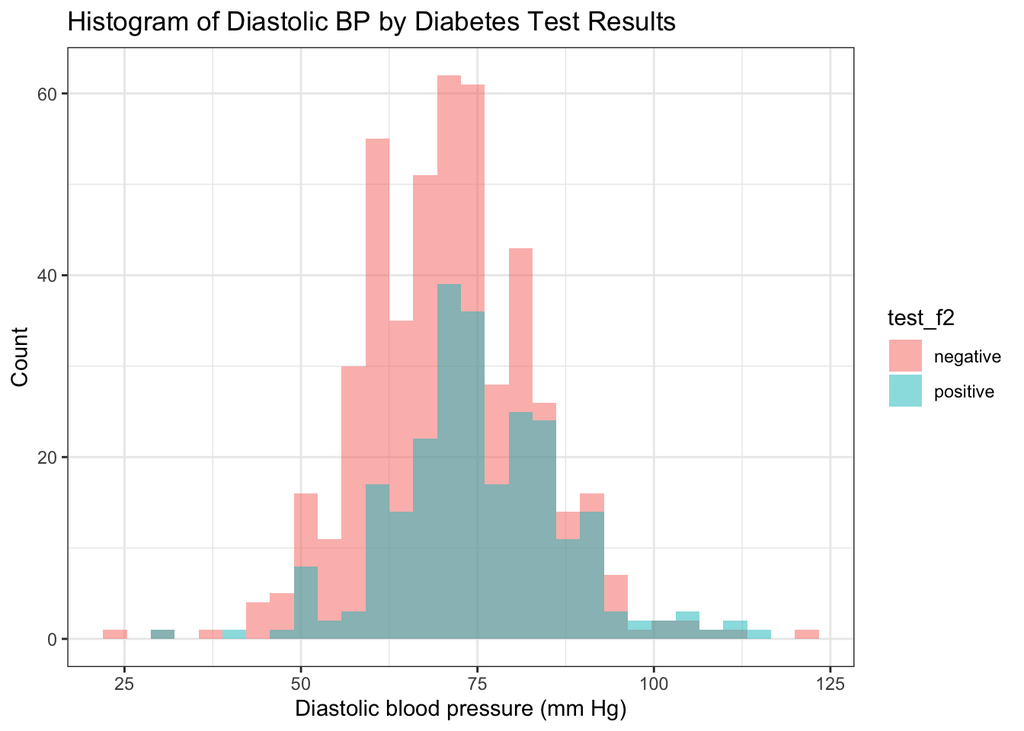

```r
ggplot(pima1, aes(x = diastolic, fill = test_f2)) +
  geom_histogram(alpha =.5, position = "identity") +
  ylab("Count") + xlab("Diastolic blood pressure (mm Hg)") +
  ggtitle("Histogram of Diastolic BP by Diabetes Test Results") +
  theme_bw()
```